# BIOS 7323 Lab 8

2018-10-29

### Objectives

Code time-dependent covariates

Check PH assumptions using time-dependent covariates

Use Stratified PH models

#### Data

The file heart_trans.csv contains data for 102 patients on a waiting list for heart transplant.

id: subject id  
delta: death indicator (0=alive, 1=died)  
futime: time from acceptance on wait list to death or end of follow-up  
surgery: prior bypass surgery indicator  
age: centered age in years at acceptance on wait list (i.e., age-48)  
trx.wait.time: time before transplant  
trx: heart transplant indicator  
era: indicator for transplant era (before or after 1971)

The primary research question is whether prior bypass surgery affects overall survival after acceptance onto the wait list.

#### Coding time-dependent covariates

Because some patients undergo heart transplantation, it is also of interest to see how this time-dependent covariate affects overall survival. We will explore the effect of transplantation using a time-transform function `tt()` and by creating a counting process dataset.

```r
#load the data from heart_trans.csv
heart_dat<-read_csv("heart_trans.csv",col_types = c("iiilddli"))

#create a variable which is equal to the time before transplant (trx.wait.time) for those who received a transplant and is greater than the maximum follow-up time otherwise
heart_dat %<>% mutate(ttrans=if_else(trx,trx.wait.time,max(futime)+1))

#using the variable you just created and tt() fit a Cox PH model that also includes surgery and age
ttfit<-coxph(Surv(futime,delta) ~ surgery + age + tt(ttrans), data=heart_dat,
             tt=function(x,t,...) (t>=x))

# what is the impact of prior bypass surgery on overall survival?


# now fit the same model by creating a counting process dataset

# using tmerge()

heart_cp_dat <- tmerge(data1=heart_dat, data2=heart_dat, id=id, death=event(futime,delta)) %>%
                tmerge(data1=.,data2=.,id=id,Ztrans=tdc(ttrans-0.5))

tmergefit <- coxph(Surv(tstart,tstop,death) ~ surgery + age + Ztrans, data=heart_cp_dat)

#  using survSplit()

#unique transplant times (w/ end shifted)
ttimes <- heart_dat %>% select(ttrans) %>% unique() %>% pull() - 0.5

heart_cp_dat2 <- survSplit(Surv(futime,delta) ~ trx.wait.time + surgery + age, cut=ttimes,
                           id="id", data=heart_dat) %>%
                 mutate(ttrx=if_else(is.na(trx.wait.time),FALSE,futime>=trx.wait.time))

survsplitfit <- coxph(Surv(tstart,futime,delta) ~ surgery + age + ttrx, data=heart_cp_dat2)

# how many rows are in your counting process dataset?
nrow(heart_cp_dat)
```

```
## [1] 169
```

```r
nrow(heart_cp_dat2)
```

```
## [1] 3156
```

```r
heart_dat %>% filter(id %in% 1:4)
```

```
## # A tibble: 4 x 9
##      id delta futime surgery    age trx.wait.time trx     era ttrans
##   <int> <int>  <int> <lgl>    <dbl>         <dbl> <lgl> <int>  <dbl>
## 1     1     1     49 FALSE   -17.2             NA FALSE     0   1800
## 2     2     1      5 FALSE     3.84            NA FALSE     0   1800
## 3     3     1     15 FALSE     6.30             0 TRUE      0      0
## 4     4     1     38 FALSE    -7.74            35 TRUE      0     35
```

```r
heart_cp_dat %>% filter(id %in% 1:4)
```

```
##   id delta futime surgery        age trx.wait.time   trx era ttrans tstart
## 1  1     1     49   FALSE -17.155373            NA FALSE   0   1800    0.0
## 2  2     1      5   FALSE   3.835729            NA FALSE   0   1800    0.0
## 3  3     1     15   FALSE   6.297057             0  TRUE   0      0    0.0
## 4  4     1     38   FALSE  -7.737166            35  TRUE   0     35    0.0
## 5  4     1     38   FALSE  -7.737166            35  TRUE   0     35   34.5
##   tstop death Ztrans
## 1  49.0     1      0
## 2   5.0     1      0
## 3  15.0     1      1
## 4  34.5     0      0
## 5  38.0     1      1
```

```r
heart_cp_dat2 %>% filter(id %in% 1:4)
```

```
##    trx.wait.time surgery        age id tstart futime delta  ttrx
## 1             NA   FALSE -17.155373  1    0.0    0.5     0 FALSE
## 2             NA   FALSE -17.155373  1    0.5    1.5     0 FALSE
## 3             NA   FALSE -17.155373  1    1.5    2.5     0 FALSE
## 4             NA   FALSE -17.155373  1    2.5    3.5     0 FALSE
## 5             NA   FALSE -17.155373  1    3.5    4.5     0 FALSE
## 6             NA   FALSE -17.155373  1    4.5    6.5     0 FALSE
## 7             NA   FALSE -17.155373  1    6.5    8.5     0 FALSE
## 8             NA   FALSE -17.155373  1    8.5   10.5     0 FALSE
## 9             NA   FALSE -17.155373  1   10.5   11.5     0 FALSE
## 10            NA   FALSE -17.155373  1   11.5   14.5     0 FALSE
## 11            NA   FALSE -17.155373  1   14.5   15.5     0 FALSE
## 12            NA   FALSE -17.155373  1   15.5   16.5     0 FALSE
## 13            NA   FALSE -17.155373  1   16.5   17.5     0 FALSE
## 14            NA   FALSE -17.155373  1   17.5   18.5     0 FALSE
```

[output cut: 59 more lines]

```r
# how do you interpret the coefficient for transplantation?

td_mods <- map(list(ttfit,tmergefit,survsplitfit),function(x) tidy(x,exponentiate=TRUE))

# --> At a given time, a person with transplant has better survival than person w/o transplant
# --> estimate for hazard of death after transplant is 0.964 hazard of death before transplant, but not statistically significant
```

#### Checking proportional hazards assumptions using time-dependent covariates

A time dependent covariate can be used to test the PH assumption for a fixed-time covariate $Z_1$ by using a known function `g(t)` to create a artifical time-dependent variable $Z_2(t)=Z_1 \times g(t)$. The model for the time-dependent covariate is:

$\lambda(t)=\lambda_0(t)\exp(\beta Z(t))$

A test of $H_0:\beta_2=0$ is a test of the PH assumption for the fixed-time covariate.

Alternatively, we can consider a time-dependent *coefficient* in the model:

$\lambda(t)=\lambda_0(t)\exp(\beta(t) Z)$

Note that in this model, the $\beta$ are a function of time and the $Z$ are constant. If the PH assumption is true $\beta(t)$ will be a horizontal line (i.e. slope = 0).

See the `Using Time Dependent Covariates` vignette in the `survival` package for more info.

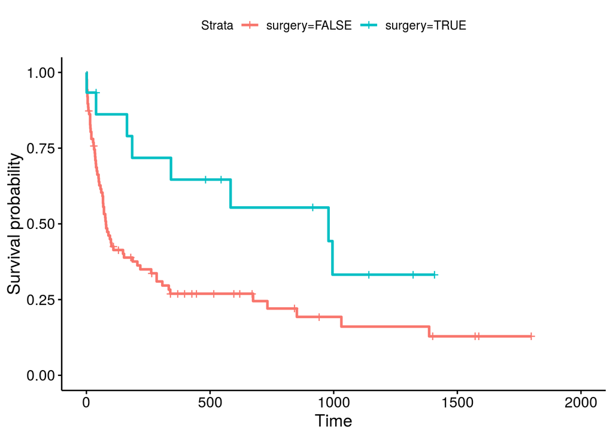

```r
ggsurvplot( survfit(Surv(futime,delta)~surgery,data=heart_dat))
```

```r
#test whether the PH assumption for surgery holds by fitting a Cox PH model with age, surgery, and the artifical time-dependent variable surgery x log(time) using tt()

fit1<-coxph(Surv(futime,delta) ~ age + surgery + tt(surgery),
            tt=function(x,t,...) x*log(t), data=heart_dat)
summary(fit1)
```

```
## Call:
## coxph(formula = Surv(futime, delta) ~ age + surgery + tt(surgery),
##     data = heart_dat, tt = function(x, t, ...) x * log(t))
##
##   n= 102, number of events= 74
##
##                 coef exp(coef) se(coef)      z Pr(>|z|)
## age          0.02920   1.02963  0.01356  2.154   0.0313 *
## surgeryTRUE -1.79486   0.16615  1.28993 -1.391   0.1641
## tt(surgery)  0.19153   1.21110  0.25356  0.755   0.4500
## ---
## Signif. codes:  0 '***' 0.001 '**' 0.01 '*' 0.05 '.' 0.1 ' ' 1
##
##             exp(coef) exp(-coef) lower .95 upper .95
## age            1.0296     0.9712   1.00263     1.057
## surgeryTRUE    0.1662     6.0186   0.01326     2.082
## tt(surgery)    1.2111     0.8257   0.73680     1.991
##
## Concordance= 0.612  (se = 0.252 )
## Rsquare= 0.114   (max possible= 0.997 )
## Likelihood ratio test= 12.38  on 3 df,   p=0.006
## Wald test            = 10.23  on 3 df,   p=0.02
## Score (logrank) test = 11  on 3 df,   p=0.01
```

```r
# Is the PH assumption is violated for surgery?


#fit a cox PH model with fixed covariates age and surgery
fit0 <- coxph(Surv(futime,delta)~ age + surgery, data=heart_dat)

#use this model fit in cox.zph() to estimate time dependent coefficients, beta(t), using a log transformation

( phtest <- cox.zph(fit0,transform='log') )
```

```
##                rho chisq     p
## age         0.0852 0.682 0.409
## surgeryTRUE 0.0883 0.533 0.465
## GLOBAL          NA 1.220 0.543
```

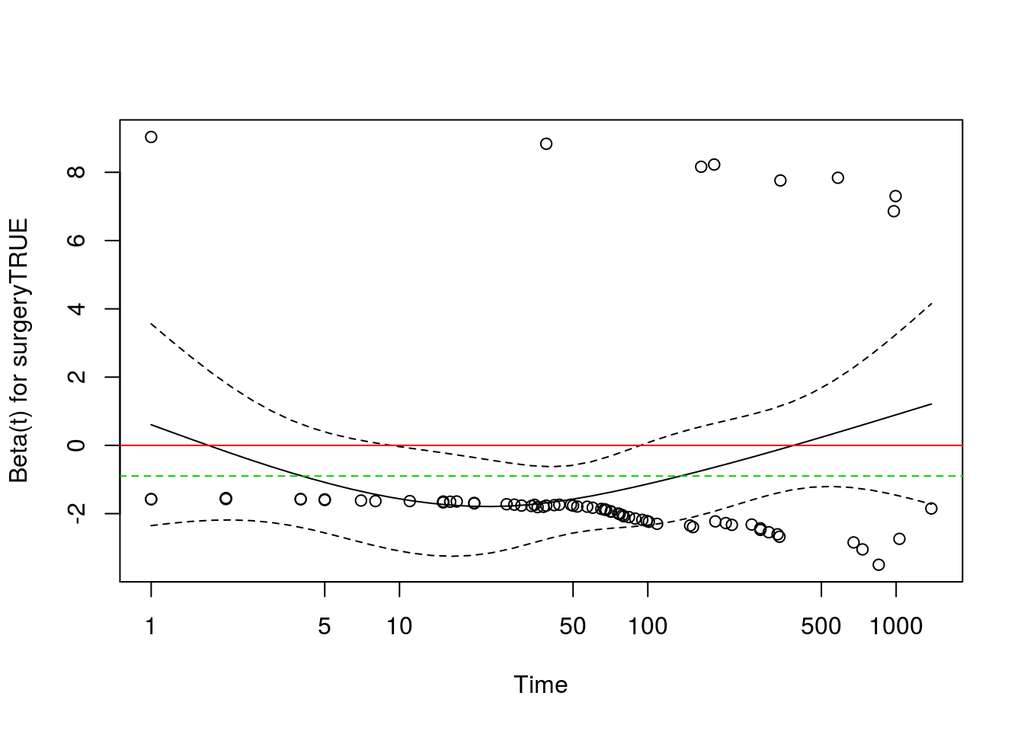

```r
# equivalent
# cox.zph(fit0,transform=function(futime) log(futime))

#plot the time-dependent coefficient for surgery
plot(phtest[2])
abline(0,0,col=2) # line for no effect
abline(h=fit0$coef[2],col=3,lty=2) # line for avg hazard over time from PH model
```

```r
# based on the test and plot of the time-dependent coefficient, does the PH assumption hold for surgery?
```

#### Stratified proportional hazards model

One approach to correct for a covariate which violated the proportional hazards assumption is to stratify on the covariate and fit a PH model for the other covariates within each strata, $j=1,\ldots,s$.

$\lambda_j(t)=\lambda_{0j}(t)\exp(\beta Z(t))$

The baseline hazards are allowed to vary across strata, but the coefficients are assumed to be the same for each strata. We can test this assumption using a likelihood ratio test or a Wald test.

```r
# fit a Cox PH model with fixed surgery and age covars, a time-dependent covariate for transplant, and a strata for each era
erafit_str<-coxph(Surv(futime,delta)~surgery+age+tt(ttrans)+strata(era),data=heart_dat,
                  tt=function(x,t,...) (t>=x))

#fit the model above separately for the patients in each era
erafit_0<-coxph(Surv(futime,delta)~surgery+age+tt(ttrans),data=subset(heart_dat,era==0),
                tt=function(x,t,...) (t>=x))

erafit_1<-coxph(Surv(futime,delta)~surgery+age+tt(ttrans),data=subset(heart_dat,era==1),
                tt=function(x,t,...) (t>=x))

# perform a likelihood ratio test for the null hypothesis of equal effects across strata
lrt <- -2*(logLik(erafit_str) - (logLik(erafit_0) + logLik(erafit_1)))

# compare to chi-sq with (s-1)*p=(2-1)*3 df
pchisq(lrt,df=(2-1)*3,lower.tail = F)
```

```
## 'log Lik.' 0.4340906 (df=3)
```

```r
# perform a Wald test of the same hypothesis

#coefficients from models in 2 strata
(strcoef<-c(erafit_0$coef, erafit_1$coef))
```

```
##    surgeryTRUE            age tt(ttrans)TRUE    surgeryTRUE            age
##    -0.84964486     0.01251022    -0.16656035    -1.20133334     0.05133485
## tt(ttrans)TRUE
##     0.20652631
```

```r
#block diagonal covar matrix
offdiag<-matrix(rep(0,9),nrow=3)
( strvar<-rbind(cbind(erafit_0$var,offdiag),cbind(offdiag,erafit_1$var)) )
```

```
##               [,1]          [,2]         [,3]          [,4]          [,5]
## [1,]  0.5338619646 -0.0002471023  0.009955815  0.0000000000  0.0000000000
## [2,] -0.0002471023  0.0002767899 -0.002604828  0.0000000000  0.0000000000
## [3,]  0.0099558155 -0.0026048282  0.196085779  0.0000000000  0.0000000000
## [4,]  0.0000000000  0.0000000000  0.000000000  0.2899995424 -0.0002262931
## [5,]  0.0000000000  0.0000000000  0.000000000 -0.0002262931  0.0005668995
## [6,]  0.0000000000  0.0000000000  0.000000000 -0.0109714123 -0.0007992372
##               [,6]
## [1,]  0.0000000000
## [2,]  0.0000000000
## [3,]  0.0000000000
## [4,] -0.0109714123
## [5,] -0.0007992372
## [6,]  0.1967278201
```

```r
#contrast matrix
C=matrix(c(1,0,0,-1,0,0,
         0,1,0,0,-1,0,
         0,0,1,0,0,-1),
         nrow=3,byrow=TRUE)

# wald test statistic
wald<-t(C%*%strcoef) %*% solve(C %*% strvar %*% t(C)) %*% (C%*%strcoef)

pchisq(wald,3,lower.tail=FALSE)
```

```
##           [,1]
## [1,] 0.4477947
```

```r
# What conclusion can you draw from these tests?

# --> not enough evidence to detect difference in covariate effects for different eras
```